# Local Authorities in the UK with high rates or numbers of COVID-19 cases

Analysis by Colin Angus with thanks to Francisco Rowe for helping me work GitHub Pages

```r
casetable
```

Local Authorities in the UK with the highest number of new COVID cases

Based on 7-day rolling average of Pillar 1 and 2 tests combined

Local Authority

Data up to<sup>1</sup>

Country

Current cases per day

Change in daily cases in the last 7 days

Last month

Total

Rate per 100,000

Total

Rate per 100,000

Birmingham

31 December

England

1,055.7

92.5

468.4 ▲

41.0

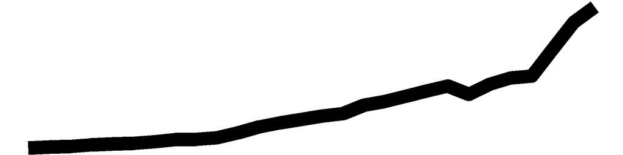

Newham

31 December

England

664.1

188.7

115.0 ▲

32.7

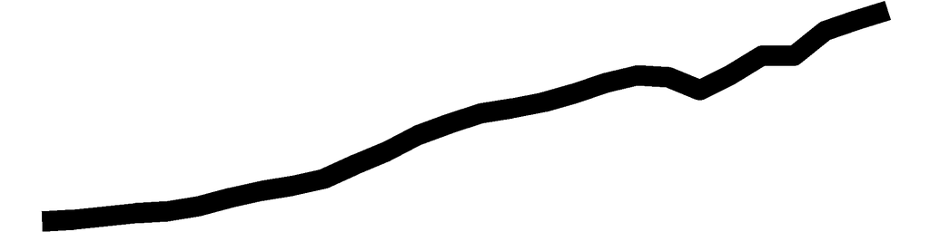

Redbridge

31 December

England

628.7

206.9

108.9 ▲

35.8

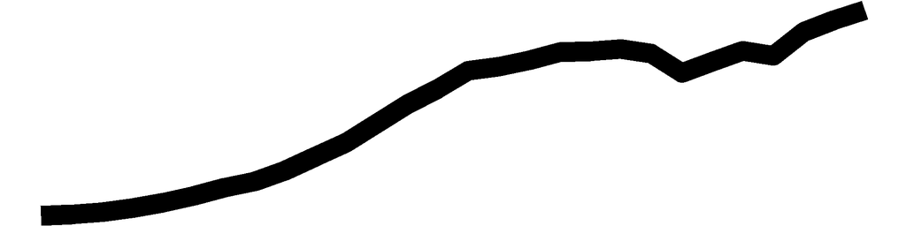

Enfield

31 December

England

578.7

173.3

47.4 ▲

14.2

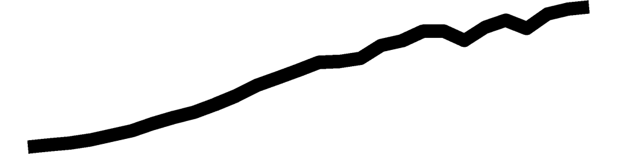

Croydon

31 December

England

572.0

148.4

82.6 ▲

21.4

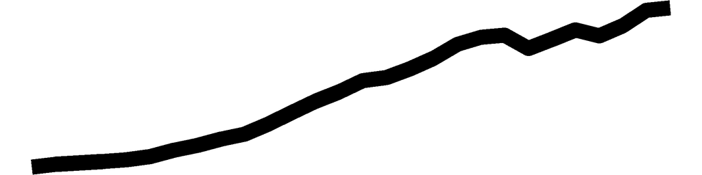

Barnet

31 December

England

552.4

140.9

57.0 ▲

14.5

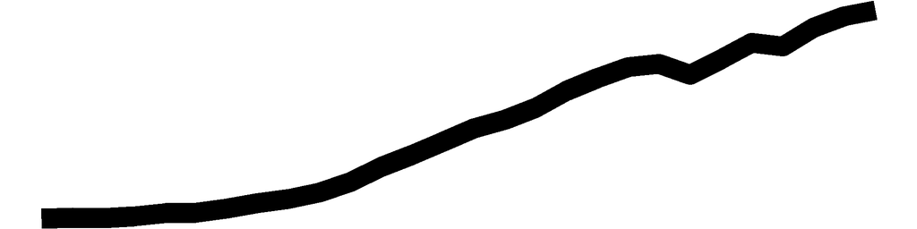

Tower Hamlets

31 December

England

546.6

172.0

60.1 ▲

18.9

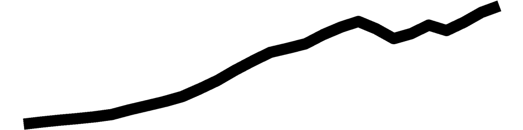

Buckinghamshire

31 December

England

506.9

93.9

74.0 ▲

13.7

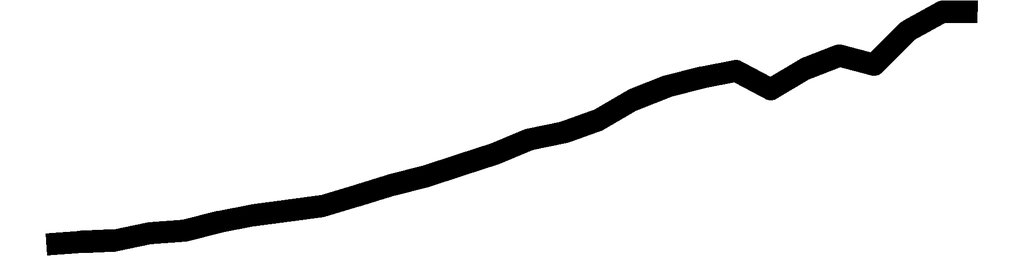

Liverpool

31 December

England

503.4

101.7

341.0 ▲

68.9

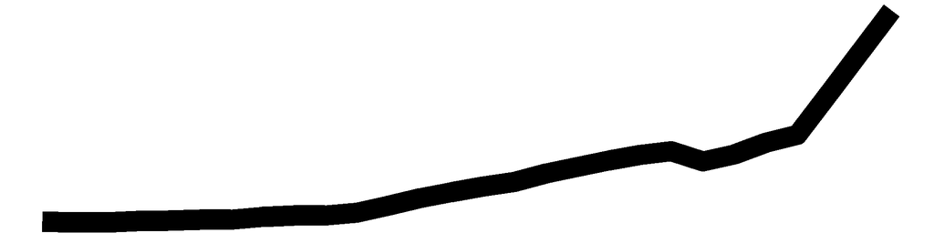

Bromley

31 December

England

501.4

151.4

51.3 ▲

15.5

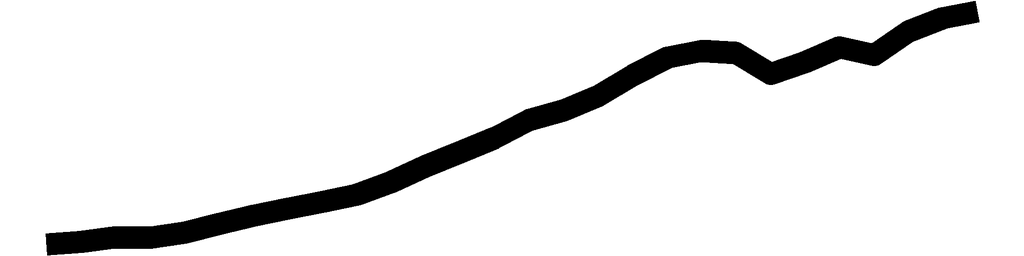

Data from PHE, PHW, DoHNI and ScotGov | Analysis by @VictimOfMaths

<sup>*1*</sup> Data from the most recent 4 days available is excluded as this is often very incomplete

```r
ratetable
```

Local Authorities in the UK with the highest rate of new COVID cases

Based on 7-day rolling average of Pillar 1 and 2 tests combined

Local Authority

Data up to<sup>1</sup>

Country

Current cases per day

Change in daily cases in the last 7 days

Last month

Rate per 100,000

Total

Rate per 100,000

Total

Barking and Dagenham

31 December

England

218.5

463.3

54.0 ▲

114.6

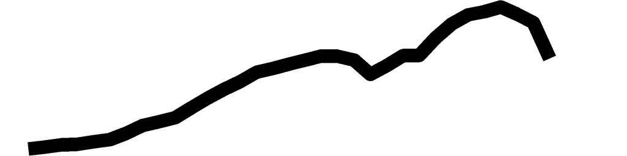

Thurrock

31 December

England

210.3

362.9

20.6 ▲

35.6

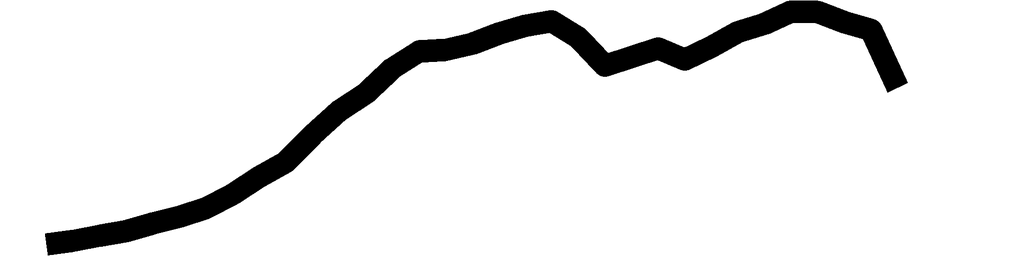

Redbridge

31 December

England

206.9

628.7

35.8 ▲

108.9

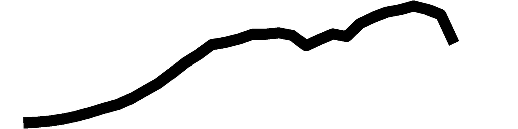

Castle Point

31 December

England

200.0

180.1

24.4 ▲

22.0

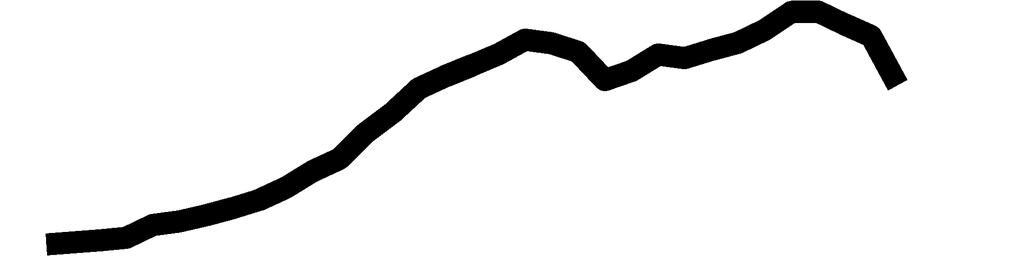

Epping Forest

31 December

England

199.2

261.3

4.9 ▲

6.4

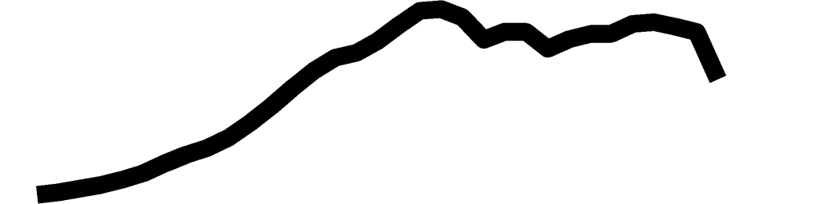

Broxbourne

31 December

England

189.6

183.7

13.7 ▲

13.3

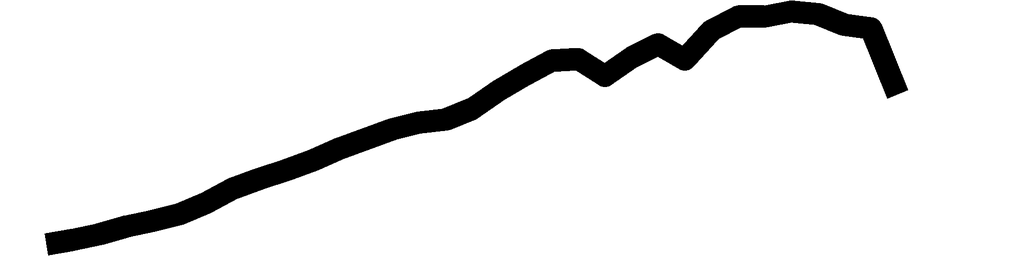

Brentwood

31 December

England

189.4

145.0

5.2 ▲

4.0

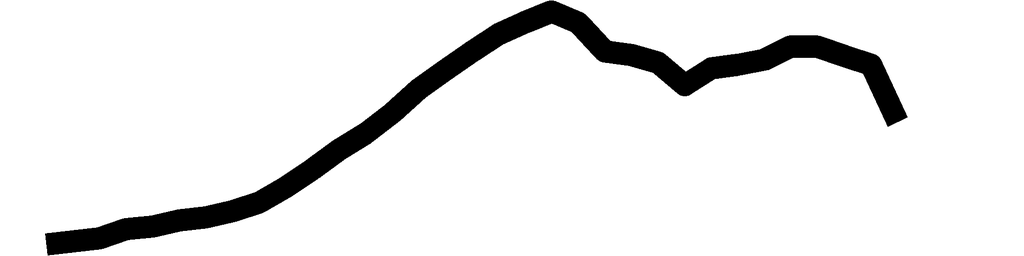

Harlow

31 December

England

188.9

163.6

26.4 ▲

22.9

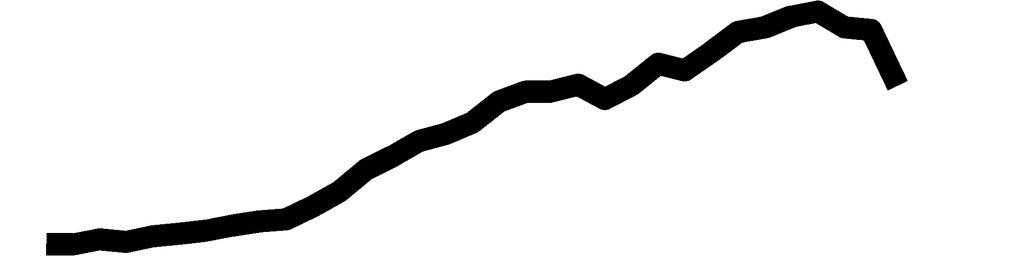

Newham

31 December

England

188.7

664.1

32.7 ▲

115.0

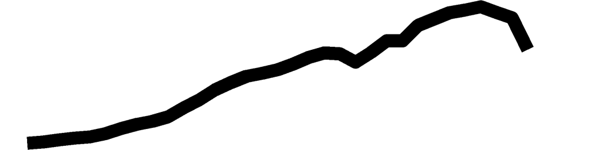

Rushmoor

31 December

England

184.7

175.7

68.9 ▲

65.6

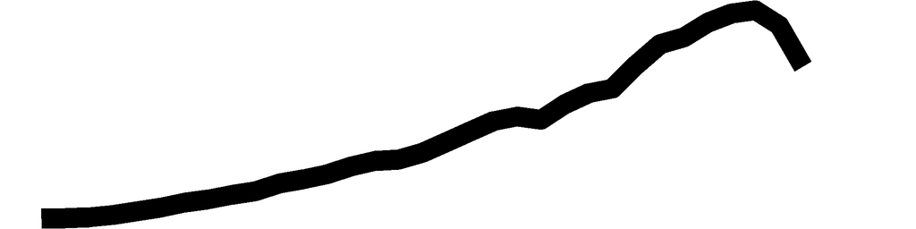

Data from PHE, PHW, DoHNI and ScotGov | Analysis by @VictimOfMaths

<sup>*1*</sup> Data from the most recent 4 days available is excluded as this is often very incomplete

```r
casechangetable
```

Local Authorities in the UK with biggest rise in new COVID-19 case numbers in the last week

Based on 7-day rolling average of Pillar 1 and 2 tests combined

Local Authority

Data up to<sup>1</sup>

Country

Change in daily cases in the last 7 days

Current cases per day

Last month

Total

Rate per 100,000

Total

Rate per 100,000

Birmingham

31 December

England

468.4 ▲

41.0

1,055.7

92.5

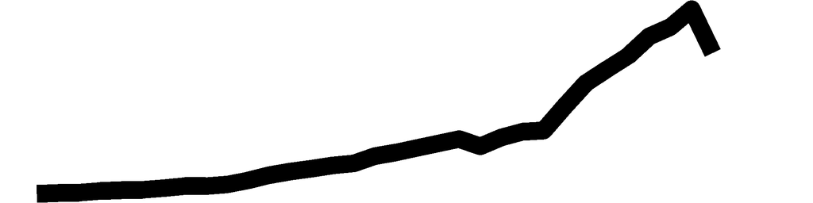

Liverpool

31 December

England

341.0 ▲

68.9

503.4

101.7

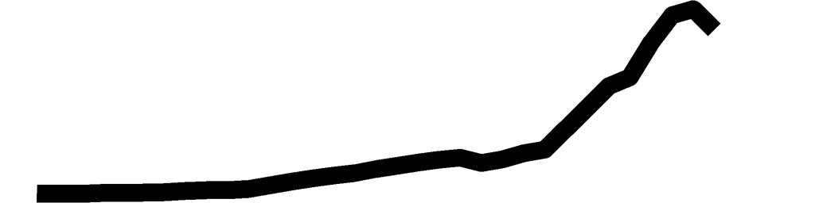

Wirral

31 December

England

219.9 ▲

68.0

345.3

106.8

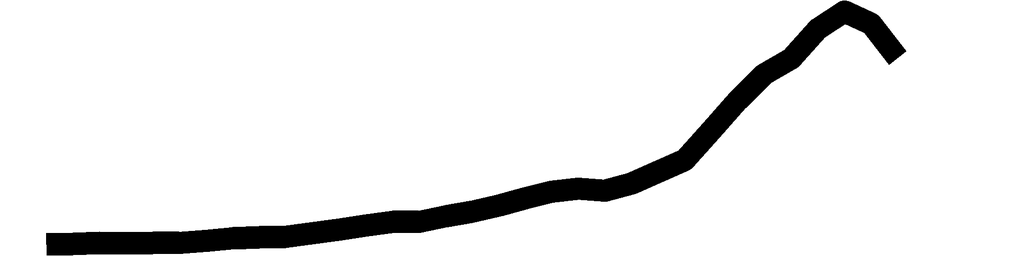

Bournemouth, Christchurch and Poole

31 December

England

218.1 ▲

55.1

372.9

94.2

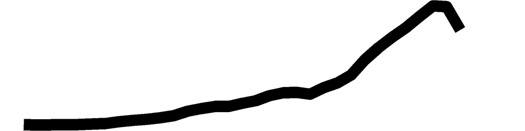

Sandwell

31 December

England

192.9 ▲

58.9

379.7

116.0

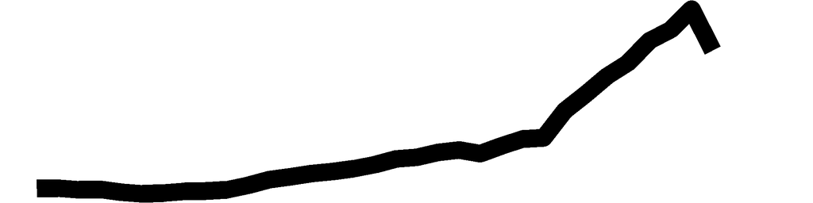

Sefton

31 December

England

188.6 ▲

68.5

278.9

101.3

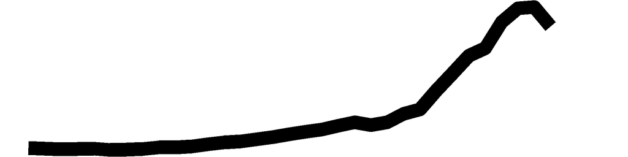

Armagh City, Banbridge and Craigavon

31 December

Northern Ireland

187.0 ▲

87.3

281.1

131.3

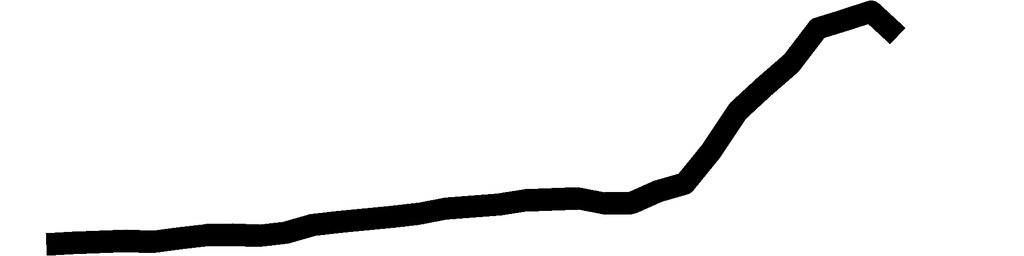

Walsall

31 December

England

168.0 ▲

59.3

302.7

106.8

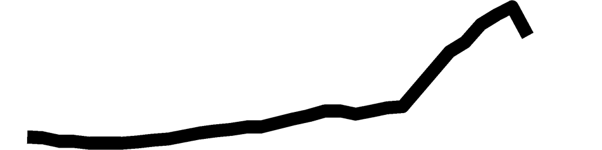

County Durham

31 December

England

163.1 ▲

31.0

375.7

71.3

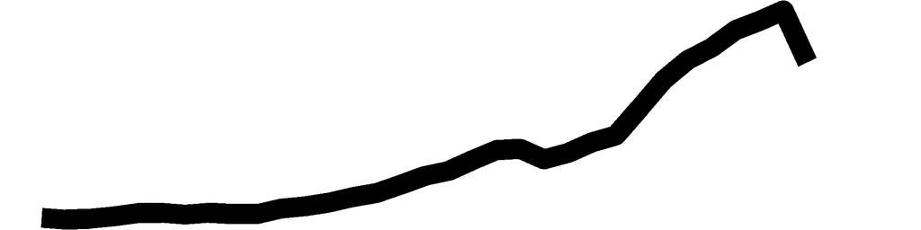

Wolverhampton

31 December

England

159.7 ▲

61.0

344.0

131.3

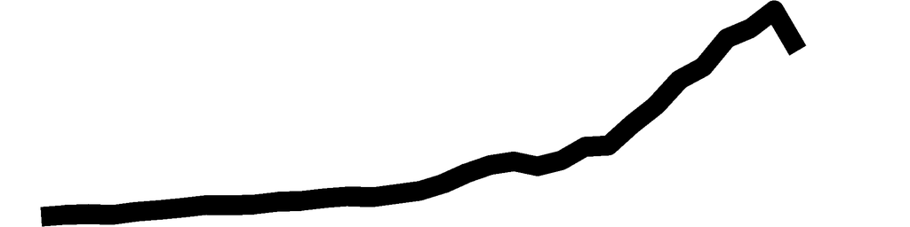

Data from PHE, PHW, DoHNI and ScotGov | Analysis by @VictimOfMaths

<sup>*1*</sup> Data from the most recent 4 days available is excluded as this is often very incomplete

```r
ratechangetable
```

Local Authorities in the UK with biggest rise in new COVID-19 case rates in the last week

Based on 7-day rolling average of Pillar 1 and 2 tests combined

Local Authority

Data up to<sup>1</sup>

Country

Change in daily cases in the last 7 days

Current cases per day

Last month

Rate per 100,000

Total

Rate per 100,000

Total

Halton

31 December

England

103.3 ▲

132.7

139.2

178.7

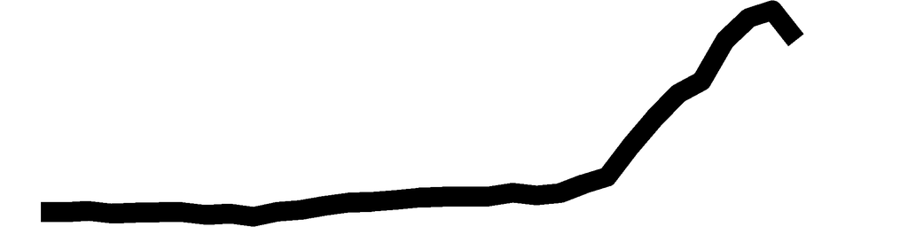

Isle of Wight

31 December

England

96.2 ▲

136.1

131.5

186.1

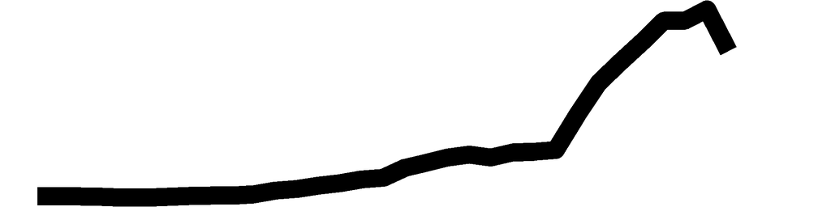

Knowsley

31 December

England

95.9 ▲

143.4

129.8

194.1

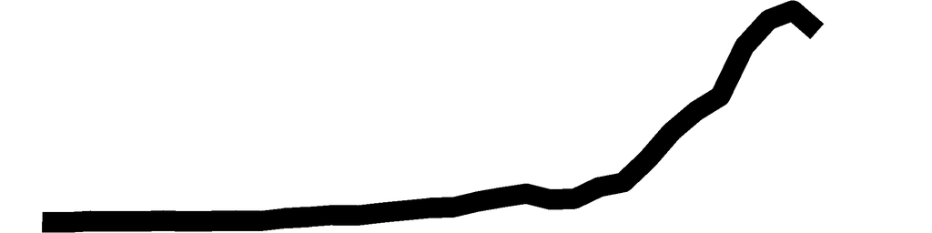

Mid Ulster

31 December

Northern Ireland

93.7 ▲

138.1

136.7

201.4

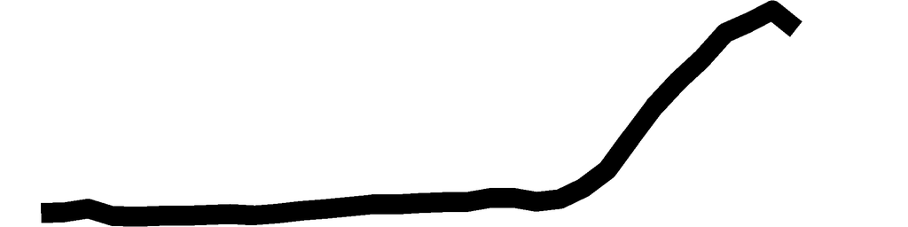

Armagh City, Banbridge and Craigavon

31 December

Northern Ireland

87.3 ▲

187.0

131.3

281.1

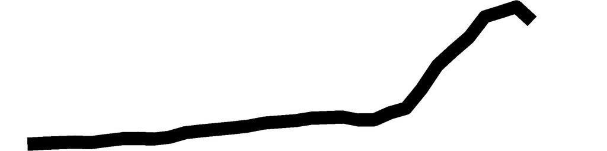

Crawley

31 December

England

84.2 ▲

94.7

158.2

177.9

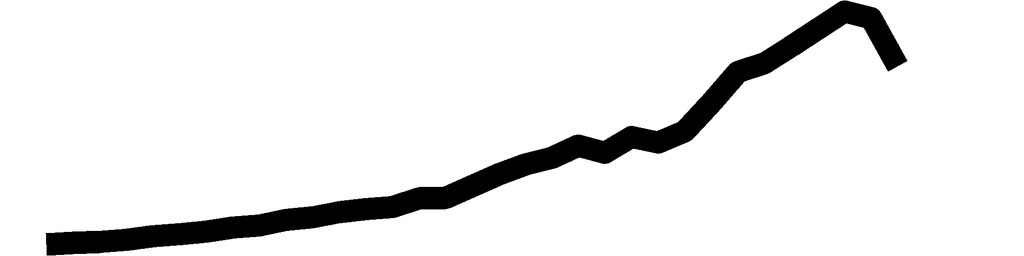

Newry, Mourne and Down

31 December

Northern Ireland

83.1 ▲

149.6

119.1

214.4

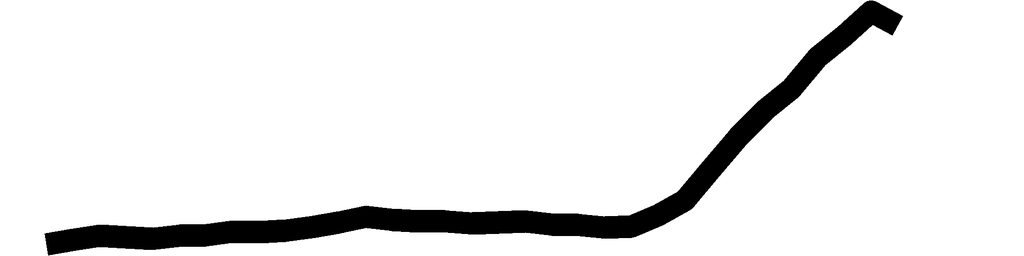

Carlisle

31 December

England

75.5 ▲

81.9

148.5

161.0

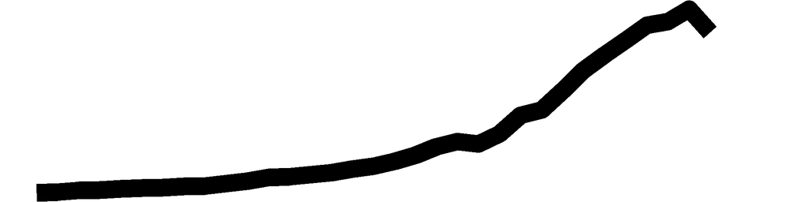

Corby

31 December

England

74.2 ▲

52.6

107.7

76.3

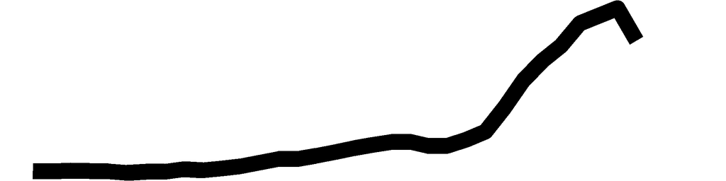

Tendring

31 December

England

70.4 ▲

102.7

133.2

194.1

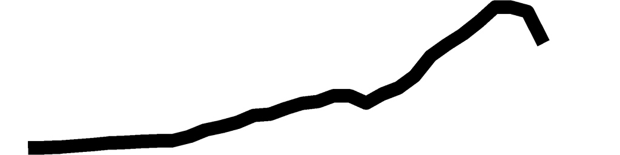

Data from PHE, PHW, DoHNI and ScotGov | Analysis by @VictimOfMaths

<sup>*1*</sup> Data from the most recent 4 days available is excluded as this is often very incomplete